# Machine Learning for Climate Risk Prediction

## Flood Risk Prediction using Explainable AI

### Objectives

- Predict flood-prone areas using environmental indicators
- Compare machine learning models
- Explain predictions using SHAP explainability
- Discuss ethical implications of AI-driven climate-risk systems

```python
import pandas as pd
import numpy as np

import matplotlib.pyplot as plt
import seaborn as sns

from sklearn.model_selection import train_test_split
from sklearn.preprocessing import StandardScaler

from sklearn.linear_model import LogisticRegression
from sklearn.ensemble import RandomForestClassifier

from sklearn.metrics import (
    accuracy_score,
    classification_report,
    confusion_matrix
)

from xgboost import XGBClassifier

import shap

import warnings
warnings.filterwarnings('ignore')
```

```python
df = pd.read_csv("data/train.csv")
```

```python
df.head()
```

|  | id | MonsoonIntensity | TopographyDrainage | RiverManagement | Deforestation | Urbanization | ClimateChange | DamsQuality | Siltation | AgriculturalPractices | ... | DrainageSystems | CoastalVulnerability | Landslides | Watersheds | DeterioratingInfrastructure | PopulationScore | WetlandLoss | InadequatePlanning | PoliticalFactors | FloodProbability |
| --- | --- | --- | --- | --- | --- | --- | --- | --- | --- | --- | --- | --- | --- | --- | --- | --- | --- | --- | --- | --- | --- |
| 0 | 0 | 5 | 8 | 5 | 8 | 6 | 4 | 4 | 3 | 3 | ... | 5 | 3 | 3 | 5 | 4 | 7 | 5 | 7 | 3 | 0.445 |
| 1 | 1 | 6 | 7 | 4 | 4 | 8 | 8 | 3 | 5 | 4 | ... | 7 | 2 | 0 | 3 | 5 | 3 | 3 | 4 | 3 | 0.450 |
| 2 | 2 | 6 | 5 | 6 | 7 | 3 | 7 | 1 | 5 | 4 | ... | 7 | 3 | 7 | 5 | 6 | 8 | 2 | 3 | 3 | 0.530 |
| 3 | 3 | 3 | 4 | 6 | 5 | 4 | 8 | 4 | 7 | 6 | ... | 2 | 4 | 7 | 4 | 4 | 6 | 5 | 7 | 5 | 0.535 |
| 4 | 4 | 5 | 3 | 2 | 6 | 4 | 4 | 3 | 3 | 3 | ... | 2 | 2 | 6 | 6 | 4 | 1 | 2 | 3 | 5 | 0.415 |

5 rows × 22 columns

```python
df.columns
```

```
Index(['id', 'MonsoonIntensity', 'TopographyDrainage', 'RiverManagement',
       'Deforestation', 'Urbanization', 'ClimateChange', 'DamsQuality',
       'Siltation', 'AgriculturalPractices', 'Encroachments',
       'IneffectiveDisasterPreparedness', 'DrainageSystems',
       'CoastalVulnerability', 'Landslides', 'Watersheds',
       'DeterioratingInfrastructure', 'PopulationScore', 'WetlandLoss',
       'InadequatePlanning', 'PoliticalFactors', 'FloodProbability'],
      dtype='object')
```

```python
df.shape
```

```
(1117957, 22)
```

```python
df = df.drop("id", axis=1)
```

```python
X = df.drop("FloodProbability", axis=1)

y = df["FloodProbability"]
```

```python
from sklearn.model_selection import train_test_split

X_train, X_test, y_train, y_test = train_test_split(
    X,
    y,
    test_size=0.2,
    random_state=42
)
```

```python
from sklearn.preprocessing import StandardScaler

scaler = StandardScaler()

X_train_scaled = scaler.fit_transform(X_train)

X_test_scaled = scaler.transform(X_test)
```

```python
from sklearn.linear_model import LinearRegression

lr_model = LinearRegression()

lr_model.fit(X_train_scaled, y_train)

lr_pred = lr_model.predict(X_test_scaled)
```

```python
from sklearn.metrics import (
    mean_absolute_error,
    mean_squared_error,
    r2_score
)

mae = mean_absolute_error(y_test, lr_pred)

mse = mean_squared_error(y_test, lr_pred)

rmse = np.sqrt(mse)

r2 = r2_score(y_test, lr_pred)

print("MAE:", mae)
print("RMSE:", rmse)
print("R2 Score:", r2)
```

```
MAE: 0.015792471363760326
RMSE: 0.02008000465862889
R2 Score: 0.8448773362840329
```

```python
from sklearn.ensemble import RandomForestRegressor

rf_model = RandomForestRegressor(
    n_estimators=100,
    random_state=42,
    n_jobs=-1
)

rf_model.fit(X_train, y_train)

rf_pred = rf_model.predict(X_test)
```

```python
rf_mae = mean_absolute_error(y_test, rf_pred)

rf_rmse = np.sqrt(mean_squared_error(y_test, rf_pred))

rf_r2 = r2_score(y_test, rf_pred)

print("Random Forest Results")
print("MAE:", rf_mae)
print("RMSE:", rf_rmse)
print("R2 Score:", rf_r2)
```

```
Random Forest Results
MAE: 0.02447473254857062
RMSE: 0.029940880090698195
R2 Score: 0.655113051951046
```

```python
from xgboost import XGBRegressor

xgb_model = XGBRegressor(
    n_estimators=200,
    learning_rate=0.05,
    max_depth=6,
    random_state=42,
    n_jobs=-1
)

xgb_model.fit(X_train, y_train)

xgb_pred = xgb_model.predict(X_test)
```

```python
xgb_mae = mean_absolute_error(y_test, xgb_pred)

xgb_rmse = np.sqrt(mean_squared_error(y_test, xgb_pred))

xgb_r2 = r2_score(y_test, xgb_pred)

print("XGBoost Results")
print("MAE:", xgb_mae)
print("RMSE:", xgb_rmse)
print("R2 Score:", xgb_r2)
```

```
XGBoost Results
MAE: 0.020486236550541676
RMSE: 0.024923343449959626
R2 Score: 0.7610207247802385
```

```python
results = pd.DataFrame({
    "Model": [
        "Linear Regression",
        "Random Forest",
        "XGBoost"
    ],
    "MAE": [
        mae,
        rf_mae,
        xgb_mae
    ],
    "RMSE": [
        rmse,
        rf_rmse,
        xgb_rmse
    ],
    "R2 Score": [
        r2,
        rf_r2,
        xgb_r2
    ]
})

results
```

|  | Model | MAE | RMSE | R2 Score |
| --- | --- | --- | --- | --- |
| 0 | Linear Regression | 0.015792 | 0.020080 | 0.844877 |
| 1 | Random Forest | 0.024475 | 0.029941 | 0.655113 |
| 2 | XGBoost | 0.020486 | 0.024923 | 0.761021 |

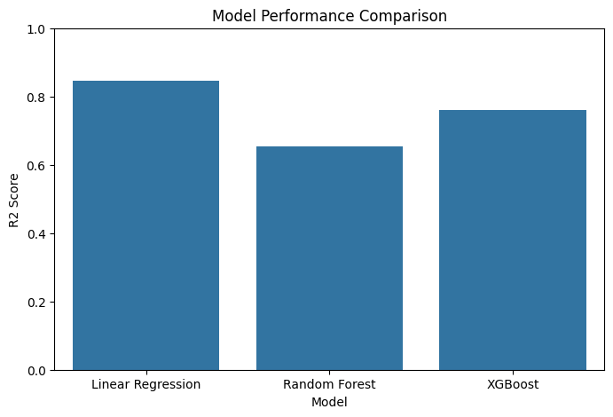

```python
plt.figure(figsize=(8,5))

sns.barplot(
    x="Model",
    y="R2 Score",
    data=results
)

plt.title("Model Performance Comparison")

plt.ylim(0,1)

plt.show()
```

```python
importance = pd.DataFrame({
    "Feature": X.columns,
    "Importance": xgb_model.feature_importances_
})

importance = importance.sort_values(
    by="Importance",
    ascending=False
)

importance.head(10)
```

|  | Feature | Importance |
| --- | --- | --- |
| 15 | DeterioratingInfrastructure | 0.057434 |
| 0 | MonsoonIntensity | 0.056786 |
| 6 | DamsQuality | 0.055753 |
| 7 | Siltation | 0.054625 |
| 2 | RiverManagement | 0.054194 |
| 1 | TopographyDrainage | 0.054119 |
| 16 | PopulationScore | 0.053403 |
| 5 | ClimateChange | 0.053219 |
| 3 | Deforestation | 0.051044 |
| 17 | WetlandLoss | 0.050773 |

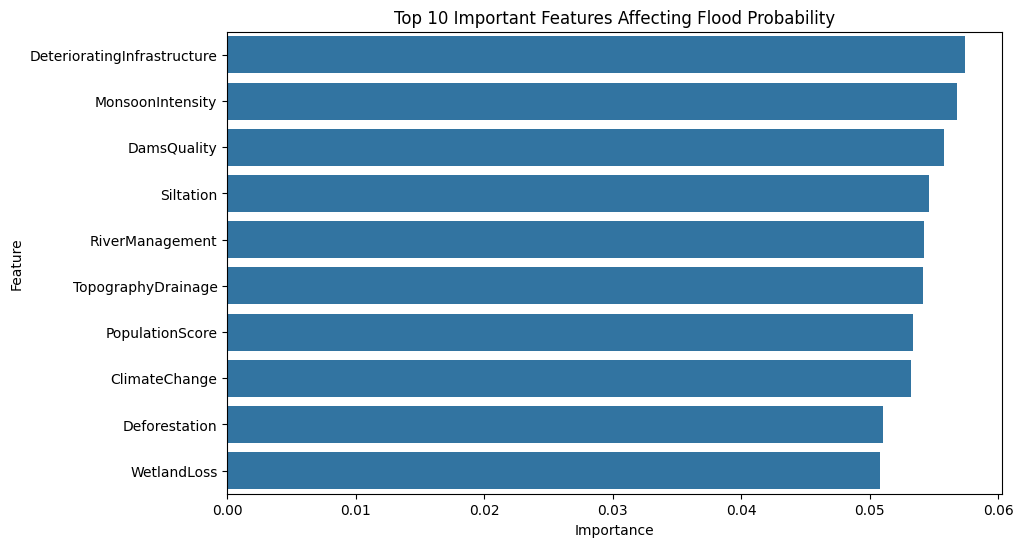

```python
plt.figure(figsize=(10,6))

sns.barplot(
    x="Importance",
    y="Feature",
    data=importance.head(10)
)

plt.title("Top 10 Important Features Affecting Flood Probability")

plt.show()
```

```python
explainer = shap.Explainer(xgb_model)

shap_values = explainer(X_test[:1000])
```

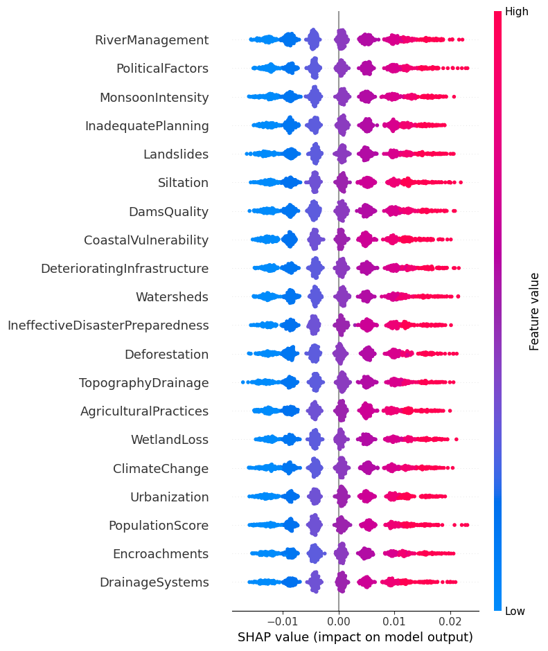

```python
shap.summary_plot(
    shap_values,
    X_test[:1000]
)
```

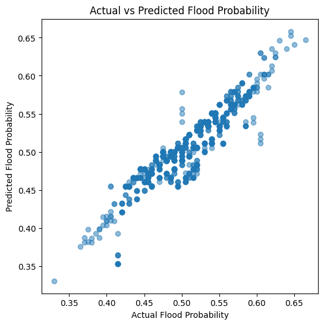

```python
plt.figure(figsize=(6,6))

plt.scatter(
    y_test[:1000],
    lr_pred[:1000],
    alpha=0.5
)

plt.xlabel("Actual Flood Probability")
plt.ylabel("Predicted Flood Probability")

plt.title("Actual vs Predicted Flood Probability")

plt.show()
```

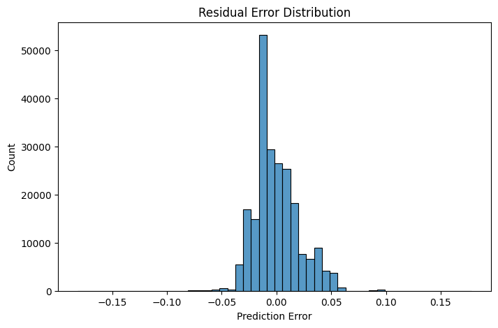

```python
residuals = y_test - lr_pred

plt.figure(figsize=(8,5))

sns.histplot(
    residuals,
    bins=50
)

plt.title("Residual Error Distribution")

plt.xlabel("Prediction Error")

plt.show()
```

# Research Questions

## RQ1

Which machine learning model provides the best predictive performance for flood probability estimation?

## RQ2

Which environmental factors contribute most significantly to flood probability prediction?

## RQ3

How can explainable AI improve transparency in climate-risk prediction systems?

## RQ4

What are the ethical implications of AI-driven flood prediction systems?

# Results and Discussion

Linear Regression achieved the strongest predictive performance with an R² score of approximately 0.845, outperforming Random Forest and XGBoost models.

The results suggest that the relationships between environmental indicators and flood probability are predominantly linear in nature.

The findings demonstrate that simpler interpretable models may outperform more complex ensemble methods when the environmental relationships within the dataset exhibit strong linear characteristics.

# Responsible AI Considerations

AI-driven climate-risk prediction systems introduce important ethical and societal considerations.

False negative predictions may result in inadequate disaster preparedness and delayed emergency response. False positive predictions may trigger unnecessary evacuations and economic disruption.

Bias within environmental datasets may reduce model reliability across underrepresented geographic regions.

Explainable AI techniques such as SHAP improve transparency and increase trustworthiness in environmental decision-support systems.

```python
import joblib

joblib.dump(lr_model, "flood_prediction_model.pkl")
```

```
['flood_prediction_model.pkl']
```